# Preparing data for analysis

## Types of variables in R

Como cualquier otro lenguaje de programación R es capaz de almacenar datos en diferentes formatos. La función **class()** nos retorna el tipo de dato de un objeto determinado.

```r
#Hacemos uso de la función class para un string
class("true")
```

```
[1] "character"
```

```r
#Hacemos uso de la función para un objeto numeríco
class(8970)
```

```
[1] "numeric"
```

```r
#Hacemos uso de class para un objeto tipo lógico
class(TRUE)
```

```
[1] "logical"
```

```r
#Hacemos uso de class para un objeto de tipo factor
class(as.factor("Orgiva"))
```

```
[1] "factor"
```

## Common type conversions

En determinadas ocasiones es necesario cambiar o coercionar el tipo de dato algún objeto. Solo determinadas coerciones están permitidas, por ejemplo, si tratamos de pasar un string como “gato” a tipo numérico esto nos dará un error. Sin embargo, existen determinadas coerciones que son bastante intuitivas, es decir, as.numeric(TRUE) se coerciona como 1.

```r
#Cargamos los datos
students <- read.csv("students_with_dates.csv")
#Vamos las estructura del dataframe
str(students)
```

```
'data.frame':   395 obs. of  33 variables:
 $ X          : int  1 2 3 4 5 6 7 8 9 10 ...
 $ school     : Factor w/ 2 levels "GP","MS": 1 1 1 1 1 1 1 1 1 1 ...
 $ sex        : Factor w/ 2 levels "F","M": 1 1 1 1 1 2 2 1 2 2 ...
 $ dob        : Factor w/ 345 levels "1996-11-02","1996-11-03",..: 313 267 113 100 162 224 79 147 292 44 ...
 $ address    : Factor w/ 2 levels "R","U": 2 2 2 2 2 2 2 2 2 2 ...
 $ famsize    : Factor w/ 2 levels "GT3","LE3": 1 1 2 1 1 2 2 1 2 1 ...
 $ Pstatus    : Factor w/ 2 levels "A","T": 1 2 2 2 2 2 2 1 1 2 ...
 $ Medu       : int  4 1 1 4 3 4 2 4 3 3 ...
 $ Fedu       : int  4 1 1 2 3 3 2 4 2 4 ...
 $ Mjob       : Factor w/ 5 levels "at_home","health",..: 1 1 1 2 3 4 3 3 4 3 ...
 $ Fjob       : Factor w/ 5 levels "at_home","health",..: 5 3 3 4 3 3 3 5 3 3 ...
 $ reason     : Factor w/ 4 levels "course","home",..: 1 1 3 2 2 4 2 2 2 2 ...
 $ guardian   : Factor w/ 3 levels "father","mother",..: 2 1 2 2 1 2 2 2 2 2 ...
 $ traveltime : int  2 1 1 1 1 1 1 2 1 1 ...
```

[output cut: 19 more lines]

```r
#Coercionamos la variable grades a tipo character
students$Grades <- as.character(students$Grades)
#Coercinamos la variable Medu a tipo factor
students$Medu <- as.factor(students$Medu)
#Coercianamos Fedu a tipo factor
students$Fedu <- as.factor(students$Fedu)
#Observamos los cambios
str(students)
```

```
'data.frame':   395 obs. of  33 variables:
 $ X          : int  1 2 3 4 5 6 7 8 9 10 ...
 $ school     : Factor w/ 2 levels "GP","MS": 1 1 1 1 1 1 1 1 1 1 ...
 $ sex        : Factor w/ 2 levels "F","M": 1 1 1 1 1 2 2 1 2 2 ...
 $ dob        : Factor w/ 345 levels "1996-11-02","1996-11-03",..: 313 267 113 100 162 224 79 147 292 44 ...
 $ address    : Factor w/ 2 levels "R","U": 2 2 2 2 2 2 2 2 2 2 ...
 $ famsize    : Factor w/ 2 levels "GT3","LE3": 1 1 2 1 1 2 2 1 2 1 ...
 $ Pstatus    : Factor w/ 2 levels "A","T": 1 2 2 2 2 2 2 1 1 2 ...
 $ Medu       : Factor w/ 5 levels "0","1","2","3",..: 5 2 2 5 4 5 3 5 4 4 ...
 $ Fedu       : Factor w/ 5 levels "0","1","2","3",..: 5 2 2 3 4 4 3 5 3 5 ...
 $ Mjob       : Factor w/ 5 levels "at_home","health",..: 1 1 1 2 3 4 3 3 4 3 ...
 $ Fjob       : Factor w/ 5 levels "at_home","health",..: 5 3 3 4 3 3 3 5 3 3 ...
 $ reason     : Factor w/ 4 levels "course","home",..: 1 1 3 2 2 4 2 2 2 2 ...
 $ guardian   : Factor w/ 3 levels "father","mother",..: 2 1 2 2 1 2 2 2 2 2 ...
 $ traveltime : int  2 1 1 1 1 1 1 2 1 1 ...
```

[output cut: 19 more lines]

## Working with dates

Las fechas pueden ser cambiadas para trabajar en cualquier lenguaje de programación, en R gracias al paquete **lubridate** trabajar con ellas es más sencillo. Este paquete combina las letras **y**, **m**, **d**, **h**, **m**, **s**. El orden de estas letras debe de machear con el orden de lectura de fecha, además no todas las combinaciones son válidas.

```r
library(lubridate)
#Hacemos uso del paquete lubridate con una determinada fecha
dmy("17 sep 2015")
```

```
[1] "2015-09-17"
```

```r
#Volvemos a hacer uso del paquete lubridate
mdy_hm("July 15, 2016 12:56")
```

```
[1] "2016-07-15 12:56:00 UTC"
```

```r
#Parseamos la columna dob a tipo fecha
students$dob <- ymd(students$dob)
#Parseamos la columna nurse_visit
students$nurse_visit <- ymd_hms(students$nurse_visit)
#Vemos los cambios
str(students)
```

```
'data.frame':   395 obs. of  33 variables:
 $ X          : int  1 2 3 4 5 6 7 8 9 10 ...
 $ school     : Factor w/ 2 levels "GP","MS": 1 1 1 1 1 1 1 1 1 1 ...
 $ sex        : Factor w/ 2 levels "F","M": 1 1 1 1 1 2 2 1 2 2 ...
 $ dob        : Date, format: "2000-06-05" "1999-11-25" "1998-02-02" "1997-12-20" ...
 $ address    : Factor w/ 2 levels "R","U": 2 2 2 2 2 2 2 2 2 2 ...
 $ famsize    : Factor w/ 2 levels "GT3","LE3": 1 1 2 1 1 2 2 1 2 1 ...
 $ Pstatus    : Factor w/ 2 levels "A","T": 1 2 2 2 2 2 2 1 1 2 ...
 $ Medu       : Factor w/ 5 levels "0","1","2","3",..: 5 2 2 5 4 5 3 5 4 4 ...
 $ Fedu       : Factor w/ 5 levels "0","1","2","3",..: 5 2 2 3 4 4 3 5 3 5 ...
 $ Mjob       : Factor w/ 5 levels "at_home","health",..: 1 1 1 2 3 4 3 3 4 3 ...
 $ Fjob       : Factor w/ 5 levels "at_home","health",..: 5 3 3 4 3 3 3 5 3 3 ...
 $ reason     : Factor w/ 4 levels "course","home",..: 1 1 3 2 2 4 2 2 2 2 ...
 $ guardian   : Factor w/ 3 levels "father","mother",..: 2 1 2 2 1 2 2 2 2 2 ...
 $ traveltime : int  2 1 1 1 1 1 1 2 1 1 ...
```

[output cut: 19 more lines]

## Trimming and padding strings

Cuando estamos en el proceso de limpieza de datos, una de las tareas comúnes es el de eliminar espacios en blanco o el de rellenar. La función **str_trim()** dentro del paquete **stringr**, nos permite eliminar los espacios en blanco al principio y al final de un string. También es posible que estemos en una situación en la que deseamos agregar un determinado valor a un string, por ejemplo, supongamos que estamos tratando los ID de una empresa, los ID de dicha empresa tiene un máximo de 7 dígitos, sin embargo, existen ID’s que tienen menos dígitos, nos puede interesar agregar estos valores faltantes con ceros, de forma que todos los ID’s tendrán un total de 7 dígitos, para esto disponemos de la función **str_pad()**. Esta función contiene los argumentos **width** mediante el cual le indicamos del tamaño que queremos que sea el string, el argumento **side** mediante el cual indicamos donde queremos agregar, y el argumento **pad** con que valor queremos agregar.

```r
#Hacemos uso de la función str_trim
str_trim(c(" Granada ", "Madrid   ", "  Barcelona"))
```

```
[1] "Granada"   "Madrid"    "Barcelona"
```

```r
#Hacemos uso de la función str_pad
str_pad(c("23485W", "8823453Q", "994Z"), width = 9, side = "left", pad = "0")
```

```
[1] "00023485W" "08823453Q" "00000994Z"
```

## Upper and lower case

También el paquete **stringr** dispone de la funciones **toupper()** y **tolower()** que nos permiten pasar a mayúscula y minúscula respectivamente.

```r
#Hacemos uso de la función toupper
toupper(c("hola", "adios"))
```

```
[1] "HOLA"  "ADIOS"
```

```r
#Hacemos uso de la función tolower
tolower(c("HOLA", "ADIOS"))
```

```
[1] "hola"  "adios"
```

## Finding and replacing strings

El paquete **stringr** proporciona dos funciones que son muy útiles a la hora de detectar y reemplazar strings: **str_detect()**y **str_replace()**. El primer argumento para estas dos funciones es el string de interés, como segundo argumento toman el patrón de interés, para el caso de **str_detect()** será aquello que estamos buscando y para el caso de **str_replace()** será aquello queremos reemplazar. La función **str_replace()** tiene un tercer argumento que es por lo que queremos sustituir.

```r
#Intentamos detectar el número 97 en la variable dob del dataframe students
str_detect(students$dob, "97")
```

```
  [1] FALSE FALSE FALSE  TRUE FALSE FALSE  TRUE FALSE FALSE  TRUE FALSE FALSE FALSE  TRUE FALSE FALSE  TRUE FALSE FALSE FALSE
 [21] FALSE FALSE  TRUE  TRUE  TRUE FALSE FALSE  TRUE FALSE FALSE FALSE FALSE FALSE FALSE  TRUE FALSE  TRUE FALSE FALSE FALSE
 [41] FALSE  TRUE  TRUE FALSE FALSE FALSE  TRUE  TRUE  TRUE  TRUE  TRUE FALSE FALSE FALSE FALSE FALSE  TRUE  TRUE FALSE FALSE
 [61] FALSE FALSE FALSE FALSE FALSE FALSE FALSE  TRUE FALSE FALSE  TRUE FALSE FALSE FALSE FALSE FALSE FALSE FALSE FALSE FALSE
 [81]  TRUE FALSE FALSE  TRUE FALSE FALSE FALSE  TRUE FALSE FALSE  TRUE  TRUE FALSE  TRUE FALSE  TRUE  TRUE FALSE  TRUE  TRUE
[101] FALSE FALSE FALSE FALSE FALSE FALSE FALSE FALSE FALSE FALSE FALSE FALSE FALSE  TRUE FALSE  TRUE FALSE FALSE FALSE FALSE
[121]  TRUE  TRUE FALSE FALSE FALSE FALSE  TRUE FALSE FALSE FALSE FALSE  TRUE FALSE FALSE FALSE FALSE  TRUE FALSE FALSE FALSE
[141]  TRUE FALSE FALSE  TRUE FALSE  TRUE FALSE FALSE  TRUE  TRUE FALSE FALSE FALSE  TRUE FALSE FALSE FALSE FALSE FALSE FALSE
[161] FALSE FALSE  TRUE FALSE  TRUE  TRUE  TRUE FALSE FALSE FALSE FALSE  TRUE  TRUE  TRUE FALSE FALSE FALSE FALSE FALSE FALSE
[181]  TRUE FALSE FALSE FALSE FALSE FALSE  TRUE FALSE  TRUE  TRUE  TRUE  TRUE FALSE FALSE FALSE FALSE FALSE FALSE FALSE FALSE
[201] FALSE FALSE FALSE FALSE FALSE FALSE FALSE FALSE FALSE  TRUE FALSE FALSE FALSE FALSE FALSE FALSE FALSE  TRUE FALSE  TRUE
[221] FALSE FALSE FALSE FALSE FALSE  TRUE  TRUE FALSE FALSE FALSE FALSE FALSE FALSE FALSE FALSE FALSE FALSE FALSE  TRUE FALSE
[241] FALSE FALSE FALSE FALSE FALSE FALSE FALSE FALSE FALSE  TRUE FALSE FALSE FALSE FALSE FALSE FALSE FALSE FALSE FALSE FALSE
[261] FALSE FALSE FALSE FALSE FALSE FALSE FALSE FALSE FALSE FALSE FALSE FALSE FALSE FALSE FALSE FALSE  TRUE FALSE FALSE FALSE
[281] FALSE  TRUE FALSE  TRUE FALSE FALSE FALSE FALSE FALSE FALSE FALSE FALSE FALSE  TRUE FALSE FALSE FALSE  TRUE FALSE FALSE
[301] FALSE FALSE FALSE FALSE FALSE FALSE FALSE FALSE FALSE FALSE FALSE FALSE FALSE FALSE FALSE FALSE FALSE FALSE FALSE FALSE
[321] FALSE FALSE FALSE FALSE FALSE FALSE FALSE  TRUE FALSE  TRUE FALSE FALSE  TRUE FALSE FALSE FALSE FALSE FALSE FALSE  TRUE
[341] FALSE FALSE  TRUE FALSE FALSE  TRUE FALSE  TRUE  TRUE FALSE FALSE FALSE FALSE FALSE FALSE FALSE  TRUE FALSE FALSE  TRUE
[361] FALSE  TRUE  TRUE FALSE FALSE FALSE FALSE FALSE FALSE FALSE FALSE FALSE FALSE  TRUE  TRUE  TRUE FALSE FALSE FALSE FALSE
[381]  TRUE  TRUE  TRUE  TRUE FALSE FALSE FALSE FALSE FALSE FALSE FALSE FALSE FALSE FALSE FALSE
```

```r
#Hacemos uso de replace
students$sex <- str_replace(students$sex, "F", "Female")
students$sex <- str_replace(students$sex, "M", "Male")
#Vemos los cambios
head(students)
```

[output not shown]

## Finding missing values

En R los valores perdidos son representado por **NA**, aunque dependiendo del fichero en el cual hagamos la extracción de los datos los valores perdidos pueden ser representados de forma alternativa. Si todos los valores perdidos son codificados como **NA**, la función **is.na()** nos ayuda a encontrar estos valores. También podemos hacer uso de las funciones **summary()** y **table()**. También podemos hacer uso de la función **any()** combinada con la función **is.na()** nos retorna el valor de **TRUE** en caso de que exista algún valor perdido y **FALSE** en caso de que no exista ninguno

```r
#Cargamos datos
social_df <- read.csv("social.csv")
#Hacemos uso de la función is.na
is.na(social_df)
```

```
      name n_friends status
[1,] FALSE     FALSE  FALSE
[2,] FALSE      TRUE  FALSE
[3,] FALSE     FALSE  FALSE
[4,] FALSE     FALSE  FALSE
```

```r
#Hacemos uso de la función any
any(is.na(social_df))
```

```
[1] TRUE
```

```r
#Hacemos uso de summary
summary(social_df)
```

```
    name     n_friends              status
 Alice:1   Min.   : 43.0               :2
 David:1   1st Qu.: 94.0   Going out!  :1
 Sarah:1   Median :145.0   Movie night…:1
 Tom  :1   Mean   :144.0
           3rd Qu.:194.5
           Max.   :244.0
           NA's   :1
```

```r
#Hacemos uso de la función table
table(social_df$status)
```

```
               Going out! Movie night…
           2            1            1
```

## Dealing with missing values

Tratar los valores perdidos es algo bastante complejo, puede que estemos simplemente interesados en eliminar todos los valores perdidos, o quizás esto no sea una opción viable, ya que podría suceder que una variable importante contenga una cantidad considerable de valores perdidos. La función **complete.cases()** se trata de una función que nos permite ver que filas no contienen valores perdidos, esta función lo que hace es retornar un vector con aquellas filas que no contienen valores perdidos. La función **na.omit()** lo que hace es eliminar aquellas filas que contienen uno o más valores perdidos.

```r
#Reemplazamos los valores vacío por valores NA
social_df$status[social_df$status == ""] <- NA
#Hacemos uso de la función complete cases
complete.cases(social_df)
```

```
[1]  TRUE FALSE  TRUE FALSE
```

```r
#Hacemos uso de la función na.omit
na.omit(social_df)
```

|  | name | n_friends | status |
| --- | --- | --- | --- |
| 1 | Sarah | 244 | Going out! |
| 3 | David | 145 | Movie night… |

## Dealing with outliers and obvious errors

Cuando tratamos valores extraños en nuestros datos, debemos decidir de si se tratan de valores erroneos que podemos eliminar o por el contrario se tratan de valores que realmente nos aportan información. La función **summary()** puede ser de gran ayuda para detectar estos valores extremos, ya que nos aporta información estadística de cada variable (máximo, mínimo etc). Por otro lado los histogramas también son útiles ya que nos muestran donde se concentran los valores de una determinada variable. Finalmente los gráficos de tipo boxpplot también son bastante útiles.

```r
#Hacemos uso de la función summary
summary(students)
```

```
       X         school       sex                 dob             address famsize   Pstatus Medu    Fedu          Mjob
 Min.   :  1.0   GP:349   Length:395         Min.   :1996-11-02   R: 88   GT3:281   A: 41   0:  3   0:  2   at_home : 59
 1st Qu.: 99.5   MS: 46   Class :character   1st Qu.:1997-11-04   U:307   LE3:114   T:354   1: 59   1: 82   health  : 34
 Median :198.0            Mode  :character   Median :1998-12-16                             2:103   2:115   other   :141
 Mean   :198.0                               Mean   :1998-10-30                             3: 99   3:100   services:103
 3rd Qu.:296.5                               3rd Qu.:1999-10-29                             4:131   4: 96   teacher : 58
 Max.   :395.0                               Max.   :2000-10-25
       Fjob            reason      guardian     traveltime      studytime        failures      schoolsup famsup     paid
 at_home : 20   course    :145   father: 90   Min.   :1.000   Min.   :1.000   Min.   :0.0000   no :344   no :153   no :214
 health  : 18   home      :109   mother:273   1st Qu.:1.000   1st Qu.:1.000   1st Qu.:0.0000   yes: 51   yes:242   yes:181
 other   :217   other     : 36   other : 32   Median :1.000   Median :2.000   Median :0.0000
 services:111   reputation:105                Mean   :1.448   Mean   :2.035   Mean   :0.3342
 teacher : 29                                 3rd Qu.:2.000   3rd Qu.:2.000   3rd Qu.:0.0000
                                              Max.   :4.000   Max.   :4.000   Max.   :3.0000
 activities nursery   higher    internet  romantic      famrel         freetime         goout            Dalc
 no :194    no : 81   no : 20   no : 66   no :263   Min.   :1.000   Min.   :1.000   Min.   :1.000   Min.   :1.000
 yes:201    yes:314   yes:375   yes:329   yes:132   1st Qu.:4.000   1st Qu.:3.000   1st Qu.:2.000   1st Qu.:1.000
                                                    Median :4.000   Median :3.000   Median :3.000   Median :1.000
                                                    Mean   :3.944   Mean   :3.235   Mean   :3.109   Mean   :1.481
                                                    3rd Qu.:5.000   3rd Qu.:4.000   3rd Qu.:4.000   3rd Qu.:2.000
                                                    Max.   :5.000   Max.   :5.000   Max.   :5.000   Max.   :5.000
      Walc           health       nurse_visit                     absences         Grades
 Min.   :1.000   Min.   :1.000   Min.   :2013-10-28 14:59:54   Min.   : 0.000   Length:395
 1st Qu.:1.000   1st Qu.:3.000   1st Qu.:2014-04-07 02:59:54   1st Qu.: 0.000   Class :character
 Median :2.000   Median :4.000   Median :2014-09-15 14:59:54   Median : 4.000   Mode  :character
 Mean   :2.291   Mean   :3.554   Mean   :2014-10-10 05:31:11   Mean   : 5.709
 3rd Qu.:3.000   3rd Qu.:5.000   3rd Qu.:2015-04-08 02:59:54   3rd Qu.: 8.000
 Max.   :5.000   Max.   :5.000   Max.   :2015-10-15 14:59:54   Max.   :75.000
```

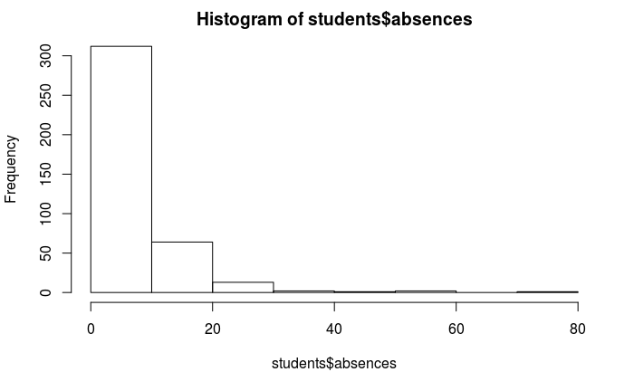

```r
#Hacemos uso del histograma en la variable absences
hist(students$absences, right = FALSE)
```

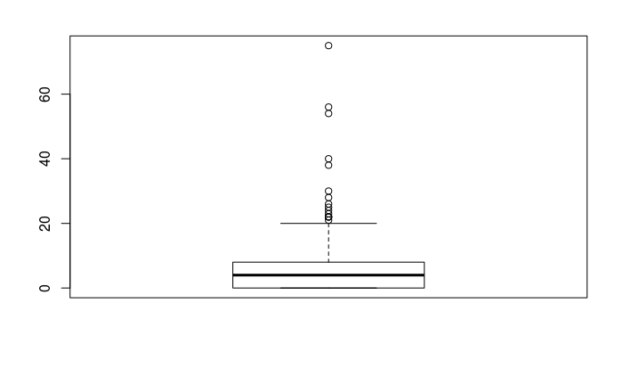

```r
#Hacemos uso de la función boxplot
boxplot(students$absences)
```